# Data Analysis for Financial Contributions to Presidential Campaigns for State of TN

Long Wan

June 7, 2016

# Abstract

The dataset chosen is the Financial Contributions to Presidential Campaigns for State of Tenneessee in 2012 since I am living in Tenneesse. I wish to find something interesting regarding presidential election donations. What kind of people were donating money to which party? How much did they donate? Which party had more advantanges over others in TN? How did people donate money to their supporting party over time? I tried to answer them by exploring the dataset.

# Basic information and cleaning data

Firstly read the dataset and have a glance at its structure.

```
## 'data.frame':    81338 obs. of  18 variables:
##  $ cmte_id          : chr  "C00495820" "C00495820" "C00431445" "C00431445" ...
##  $ cand_id          : Factor w/ 14 levels "P00003608","P20002523",..: 12 12 13 13 13 13 13 12 13 13 ...
##  $ cand_nm          : Factor w/ 14 levels "Bachmann, Michele",..: 8 8 7 7 7 7 7 8 7 7 ...
##  $ contbr_nm        : Factor w/ 19543 levels "360 GREEN MEDSURANCE MANAGEMENT L.L.C.",..: 14096 10812 9146 8649 9214 5047 17647 18196 1750 17240 ...
##  $ contbr_city      : Factor w/ 555 levels "ADAMS","ADAMSVILLE",..: 250 122 256 366 53 343 488 441 535 366 ...
##  $ contbr_st        : Factor w/ 1 level "TN": 1 1 1 1 1 1 1 1 1 1 ...
##  $ contbr_zip       : int  37659 385589005 379273353 37208 370276554 371222119 380690116 378573427 37185 37212 ...
##  $ contbr_employer  : Factor w/ 7510 levels "","(SELF)-DESIGN GROUP ONE",..: 6317 4571 5286 7276 5594 5286 5286 5273 5286 3999 ...
##  $ contbr_occupation: Factor w/ 4251 levels ""," ASSISTANT MANAGER",..: 1268 3252 3252 1044 2379 3252 3250 2425 3252 2898 ...
##  $ contb_receipt_amt: num  50 50 30 250 250 100 100 25 10 300 ...
##  $ contb_receipt_dt : Factor w/ 621 levels "01-APR-12","01-AUG-11",..: 107 107 390 431 608 496 62 107 526 151 ...
##  $ receipt_desc     : Factor w/ 20 levels "","REATTRIBUTED",..: 1 1 1 1 1 1 1 1 1 1 ...
##  $ memo_cd          : Factor w/ 2 levels "","X": 1 1 1 1 1 1 1 1 1 1 ...
##  $ memo_text        : Factor w/ 49 levels "","*","* EARMARKED CONTRIBUTION: SEE BELOW",..: 1 1 1 1 1 1 1 1 1 1 ...
##  $ form_tp          : Factor w/ 3 levels "SA17A","SA18",..: 1 1 1 1 1 1 1 1 1 1 ...
##  $ file_num         : int  779227 779227 756218 756218 756218 756218 756218 779227 756218 756218 ...
##  $ tran_id          : Factor w/ 69206 levels "0000029","0000596",..: 1968 1969 4481 4485 4930 4346 4416 1953 4783 4228 ...
##  $ election_tp      : Factor w/ 7 levels "","G2008","G2012",..: 7 7 7 7 7 7 7 7 7 7 ...
```

The dataset has 18 variables. I notice that “cmte_id”, “cand_id”, “file_num”, and “tran_id” seem to have nothing to do with the following analysis.I checked their meaning by looking into the dictionary. “cmte_id” is a 9-character alpha-numeric code assigned to a committee by the Federal Election Commission. It is not important. “cand_id” is a 9-character alpha-numeric code assigned to a candidate by the Federal Election Commission. We have already had candidate name, so the ids are not essential. “file_num” is a unique number assigned to a report and all its associated transactions.This file number can be used to link transactions to the report summaries. Since we do not need to link to the report summaries, we can leave them out temperarily. “tran_id” is a unique identifier permanently associated with each itemization or transaction appearing in an FEC electronic file. It is not important. Also, variable “contbr_st” is meaningless, since this table is for state of TN only. So I deleted these variables to simplify the dataset.

Next, I am gonna change data types. The absolute value of contbr_zip has no mathematical meaning, so I change it from int to factor. Contb_receipt_dt should be switched to date format. Besides, zip codes do not have united formates. Some are 5 digit number while some are 9 digit number. I extract the first 5 digit from those of 9 digit.

Then I would like to add a colunmn called cand_party, representing each candidate’s party.

```
##  [1] "Bachmann, Michele"              "Cain, Herman"
##  [3] "Gingrich, Newt"                 "Huntsman, Jon"
##  [5] "Johnson, Gary Earl"             "McCotter, Thaddeus G"
##  [7] "Obama, Barack"                  "Paul, Ron"
##  [9] "Pawlenty, Timothy"              "Perry, Rick"
## [11] "Roemer, Charles E. 'Buddy' III" "Romney, Mitt"
## [13] "Santorum, Rick"                 "Stein, Jill"
```

See that there were 14 presidential candidates who received donations from TN. I would create lists to group them by party.

Now I got a datawet with 13 varialbes and 81338 observations. Summary the dataset.

```
##            cand_nm                      contbr_nm          contbr_city
##  Obama, Barack :47035   SULLIVAN, NANCY MRS. :  122   NASHVILLE  :14078
##  Romney, Mitt  :28048   CHANDRA, ANUJ        :  107   MEMPHIS    : 8446
##  Paul, Ron     : 2828   CATCHINGS, CHERYL    :   95   KNOXVILLE  : 8350
##  Gingrich, Newt: 1145   SPIEGEL, HARRIETTE L.:   94   BRENTWOOD  : 3210
##  Santorum, Rick:  915   HERRING, MASON       :   90   FRANKLIN   : 3066
##  Cain, Herman  :  509   CANNON, BETSY        :   86   CHATTANOOGA: 3059
##  (Other)       :  858   (Other)              :80744   (Other)    :41129
##   contbr_zip                                      contbr_employer
##  Length:81338       RETIRED                               :16859
##  Class :character   SELF-EMPLOYED                         : 8333
##  Mode  :character   NOT EMPLOYED                          : 3959
##                     INFORMATION REQUESTED PER BEST EFFORTS: 3667
##                     INFORMATION REQUESTED                 : 1973
##                     (Other)                               :46509
##                     NA's                                  :   38
##                               contbr_occupation contb_receipt_amt
##  RETIRED                               :18712   Min.   :-5000.0
##  INFORMATION REQUESTED PER BEST EFFORTS: 3528   1st Qu.:   25.0
##  PHYSICIAN                             : 2884   Median :   60.0
##  HOMEMAKER                             : 2307   Mean   :  225.8
##  ATTORNEY                              : 2174   3rd Qu.:  200.0
##  (Other)                               :51726   Max.   :10000.0
##  NA's                                  :    7
##  contb_receipt_dt                         receipt_desc   memo_cd
##  Min.   :2007-12-27                             :80505    :60287
##  1st Qu.:2012-06-28   Refund                    :  400   X:21051
##  Median :2012-09-14   REDESIGNATION FROM PRIMARY:   75
##  Mean   :2012-07-29   REDESIGNATION TO GENERAL  :   75
##  3rd Qu.:2012-10-16   REATTRIBUTION FROM SPOUSE :   62
##  Max.   :2012-12-31   REATTRIBUTION TO SPOUSE   :   60
##                       (Other)                   :  161
##                              memo_text     election_tp
##                                   :60060        :    7
##  TRANSFER FROM ROMNEY VICTORY INC.:11536   G2008:   10
##  * OBAMA VICTORY FUND 2012        : 9070   G2012:46431
##  REDESIGNATION FROM PRIMARY       :   75   O2012:   33
##  REDESIGNATION TO GENERAL         :   75   P    :    4
##  *                                :   69   P2008:    3
##  (Other)                          :  453   P2012:34850
##        cand_party
##  Democratic :47035
##  Green      :   15
##  Libertarian:   40
##  Republican :34248
##
##
##
```

See that there are several NAs in contbr_occupation and contbr_employer. That does not matter because NA number is small. I also notice that some contribution amounts are negative, and that is because of refund displayed from receipt_desc. There is something strange that some election_tp are concerning to 2008. Look at their memo texts to see if there are any explanations.

```
##  [1]        Refund Refund Refund Refund Refund Refund Refund Refund Refund
## [11] Refund Refund Refund
## 20 Levels:  REATTRIBUTED ... SEE REATTRIBUTION
```

There are all refunds regarding donation of year 2008. Next I am gonna add a new variable called ele_tp to represent its election type(primary, general or others) by extracting the first alphabet.

Fanlly I get a 14-variable dataset. Look at the head of it.

```
##         cand_nm            contbr_nm  contbr_city contbr_zip
## 1     Paul, Ron QUILLEN, CHRIS A MR. JONESBOROUGH      37659
## 2     Paul, Ron       MAHER, MARK A.   CROSSVILLE      38558
## 3 Obama, Barack         JONES, SONNY    KNOXVILLE      37927
## 4 Obama, Barack    IVEY, WILLIAM J J    NASHVILLE      37208
## 5 Obama, Barack       JUDGE, CHARLES    BRENTWOOD      37027
## 6 Obama, Barack    ELDER, DOROTHY A. MOUNT JULIET      37122
##              contbr_employer contbr_occupation contb_receipt_amt
## 1 TENNESSEE VALLEY AUTHORITY          ENGINEER                50
## 2                       NONE           RETIRED                50
## 3                    RETIRED           RETIRED                30
## 4      WANDERBILT UNIVERISTY          DIRECTOR               250
## 5              SELF-EMPLOYED          MUSICIAN               250
## 6                    RETIRED           RETIRED               100
##   contb_receipt_dt receipt_desc memo_cd memo_text election_tp cand_party
## 1       2011-12-06                                      P2012 Republican
## 2       2011-12-06                                      P2012 Republican
## 3       2011-08-20                                      P2012 Democratic
## 4       2011-08-22                                      P2012 Democratic
## 5       2011-09-30                                      P2012 Democratic
## 6       2011-07-25                                      P2012 Democratic
##   ele_tp
## 1      P
## 2      P
## 3      P
## 4      P
## 5      P
## 6      P
```

# Analysis

After cleaning and updating the data, I have got some ideas about the data structure and how I would explore it. I will try to get some meaningful features about donations from TN. First I would like to see the donation amount distribution.

## Donation amount distribution

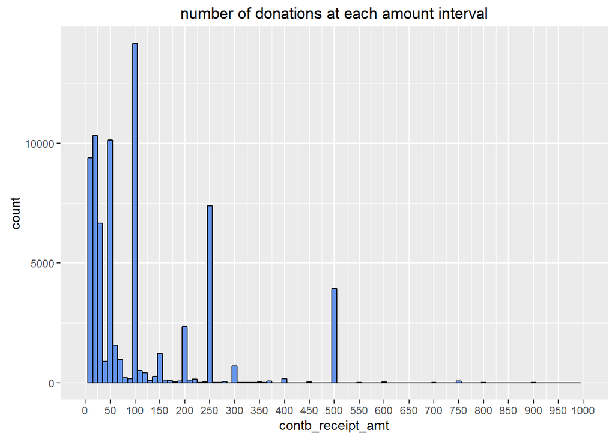

As we can see from the graph above, most donation amount are under 100 dollars. What’s more, contributors tended to donate some centain amount of like 100, 150, 200, 250, 300 and 500 dollars, compared to neighboring amount. I should mention that the amount ranged from -5000 to 10000 dollars, however, the number of them is too small so I limit the range displayed between 0 and 1000. This graph seems skew. I decide to use log10 x-axis to make it look more balanced.

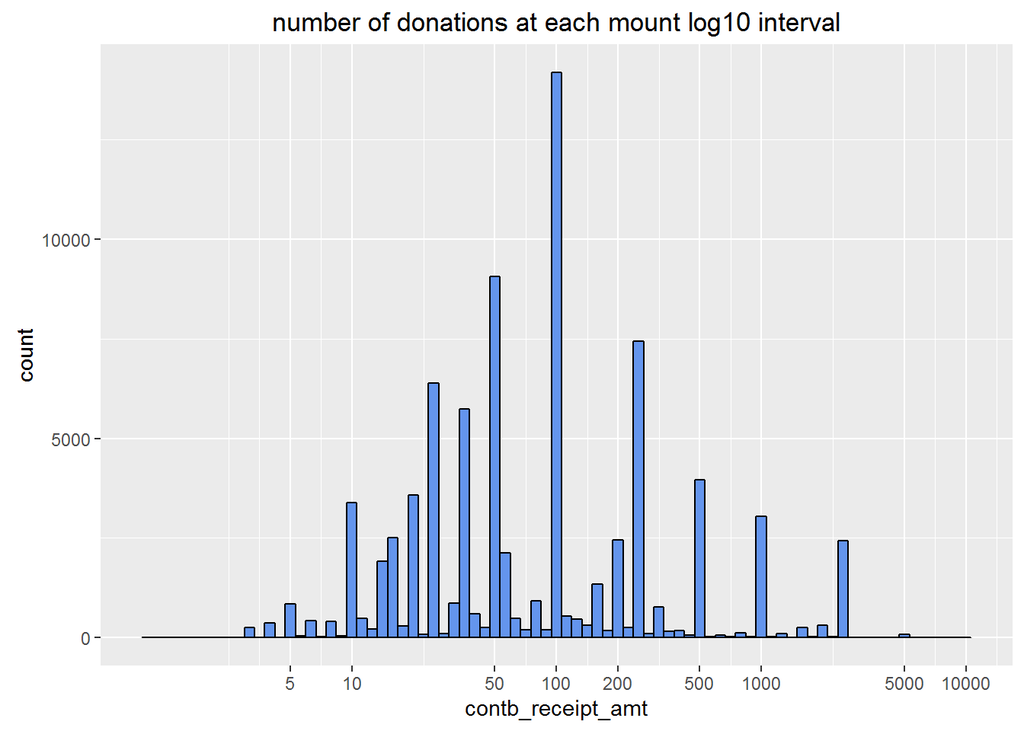

Knowing the amount distribution, I am trying to know where did these donations flow into. In other words, how much did each candidate receive. ## Donation and candidates I should group them by candidate name firstly and sum the amount of money.

```
## Source: local data frame [14 x 4]
##
##                           cand_nm     sum_amt  cand_party     n
##                            (fctr)       (dbl)      (fctr) (int)
## 1                    Romney, Mitt 12049698.25  Republican 28048
## 2                   Obama, Barack  4689914.55  Democratic 47035
## 3                     Perry, Rick   409352.00  Republican   343
## 4                       Paul, Ron   370072.89  Republican  2828
## 5                  Gingrich, Newt   266658.72  Republican  1145
## 6                  Santorum, Rick   215494.05  Republican   915
## 7                    Cain, Herman   214272.53  Republican   509
## 8               Bachmann, Michele    69014.50  Republican   283
## 9                   Huntsman, Jon    54900.00  Republican    66
## 10              Pawlenty, Timothy    10105.00  Republican    17
## 11             Johnson, Gary Earl     9748.00 Libertarian    40
## 12 Roemer, Charles E. 'Buddy' III     6140.12  Republican    92
## 13                    Stein, Jill     2975.00       Green    15
## 14           McCotter, Thaddeus G      290.00  Republican     2
```

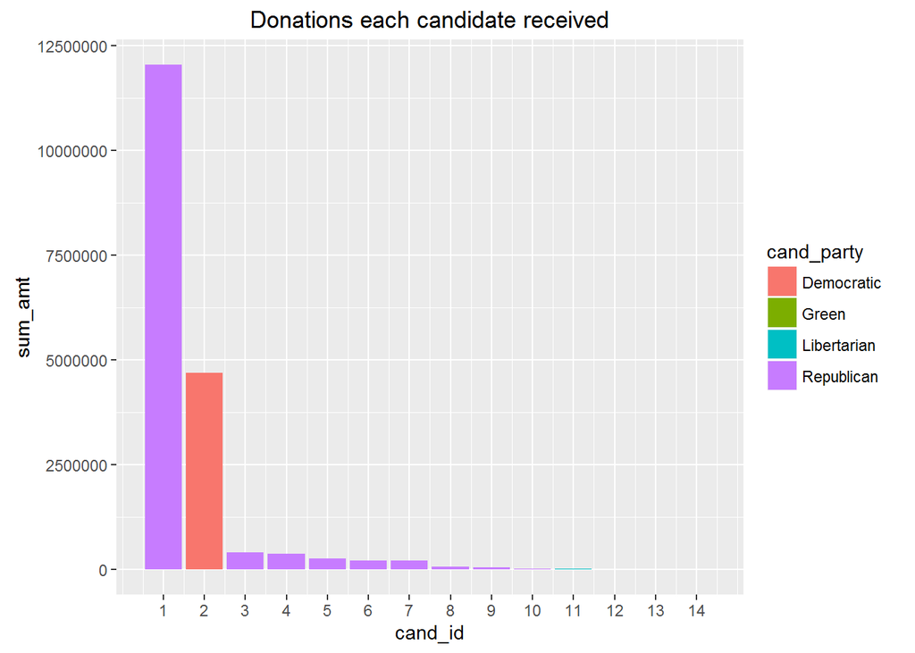

In this graph, each number corresponds to a candidate name in the table showed above. Romney received the greatest amount donations from the public while Obama took the second place. The two candidates were far ahead of others. Then I want to know something about average donation per donator for each candidate.

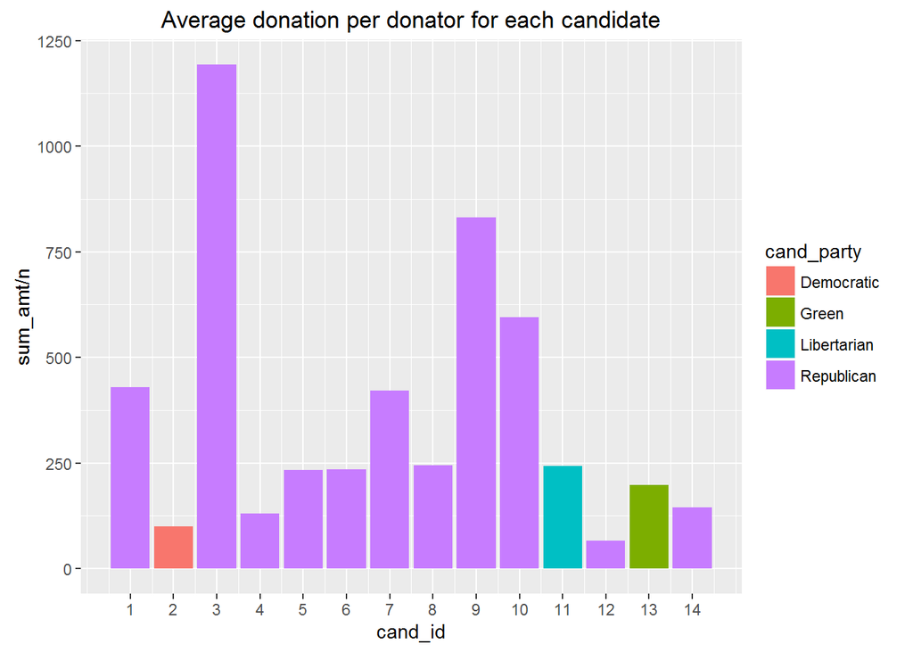

## Donation and party

Firstly show the total donation amount distribution of different parties. It would be better to draw a boxplot.

Summary of Republican donation

```
##    Min. 1st Qu.  Median    Mean 3rd Qu.    Max.
##   -5000      50     110     399     300   10000
```

Summary of Democratic donation

```
##     Min.  1st Qu.   Median     Mean  3rd Qu.     Max.
## -4990.00    19.00    50.00    99.71   100.00  5000.00
```

Summary of Green donation

```
##    Min. 1st Qu.  Median    Mean 3rd Qu.    Max.
##    25.0   100.0   250.0   198.3   250.0   300.0
```

Summary of Libertarian donation

```
##    Min. 1st Qu.  Median    Mean 3rd Qu.    Max.
##    25.0   187.2   250.0   243.7   250.0   500.0
```

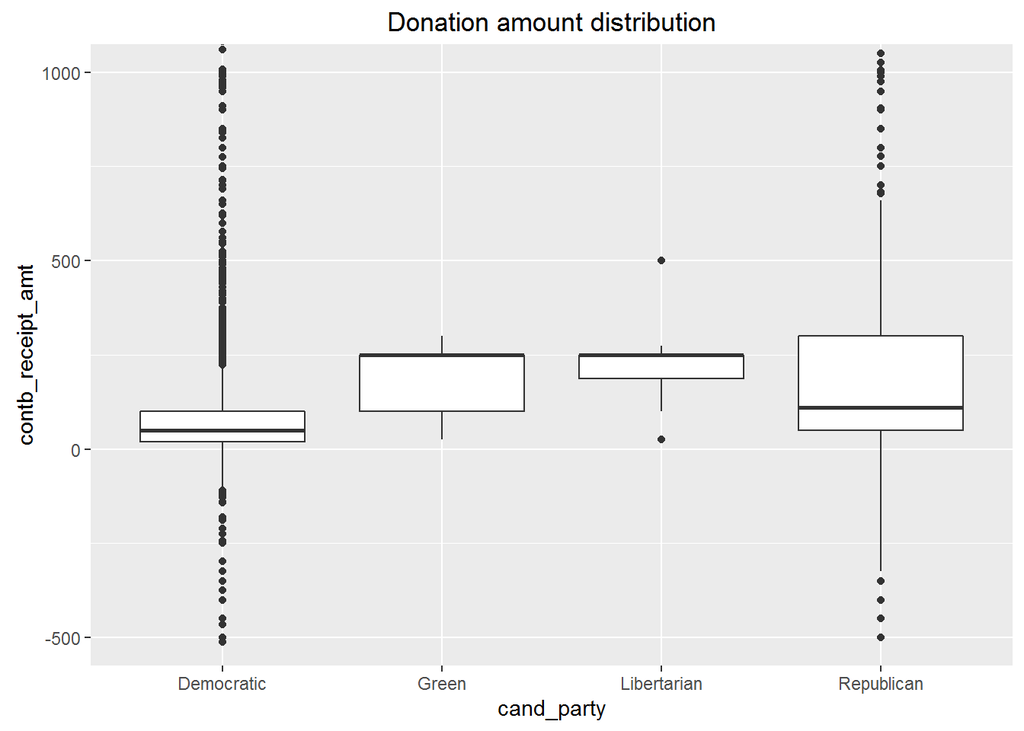

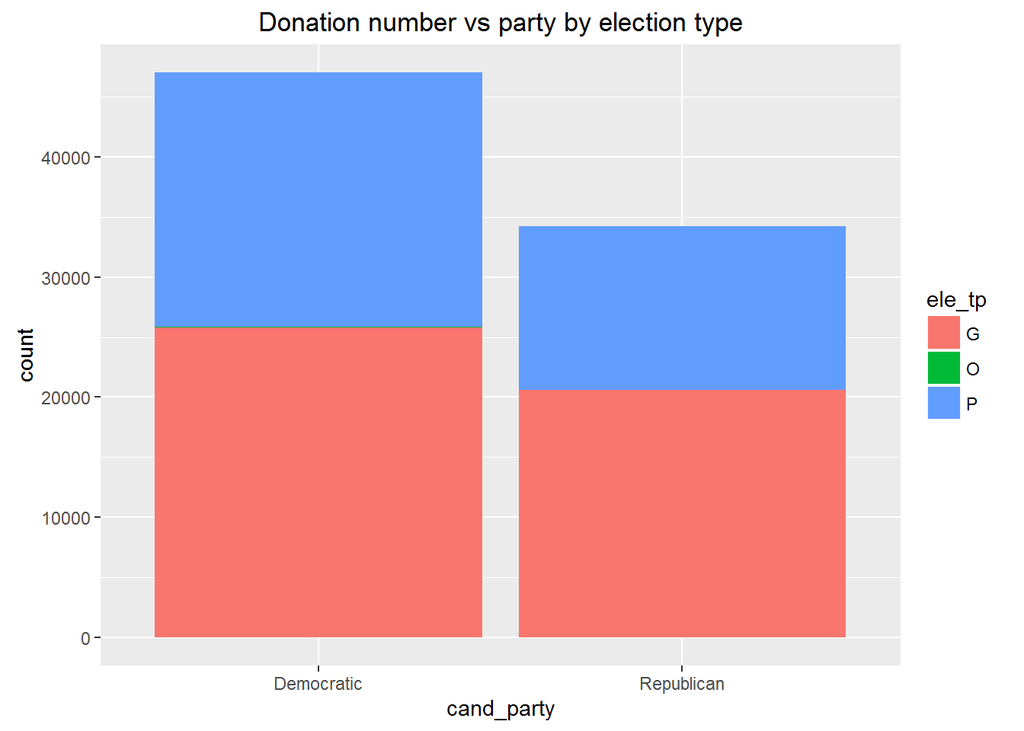

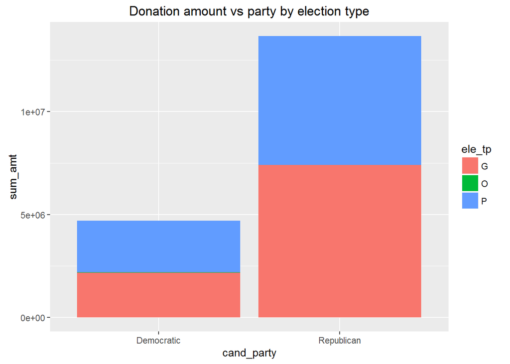

From the two graphs, I learn that Republican supporters were more active in general election than in primary election compared to Democaric supporters, since Republican donations grew faster than Democratic donations not only in donation number but also in donation amount throughout two periods. It was probably because of Romney’s pessimistic election prospect, encouraging more supporters to come forward.

So next I move forward to see the time series. How did the donation number and amount change throughout the time?

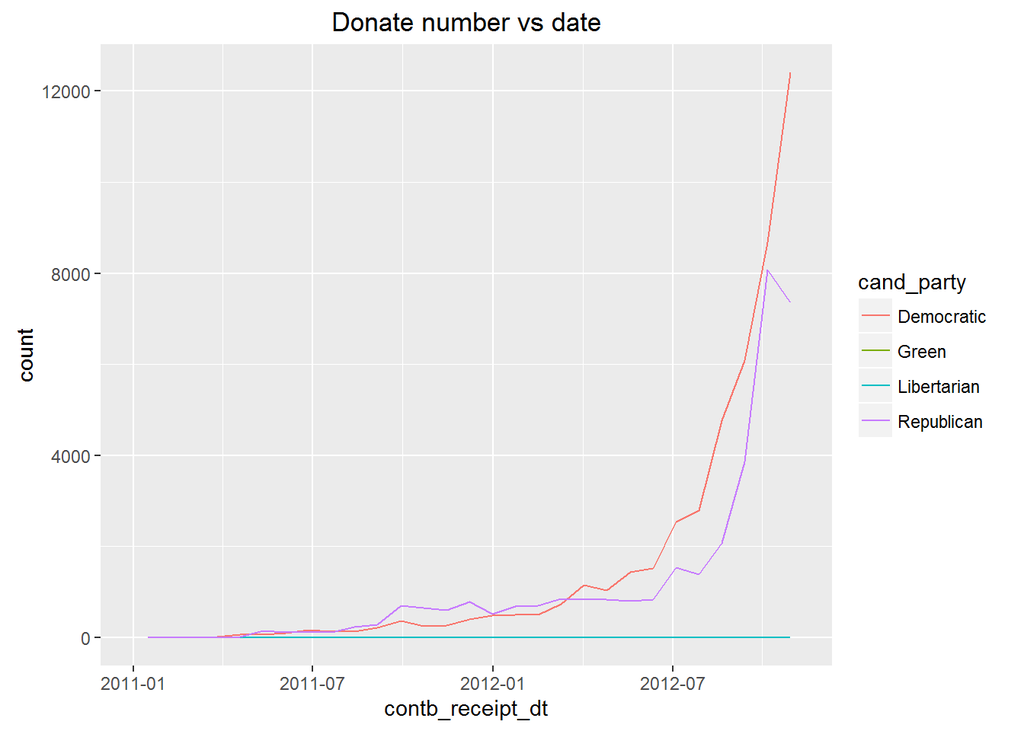

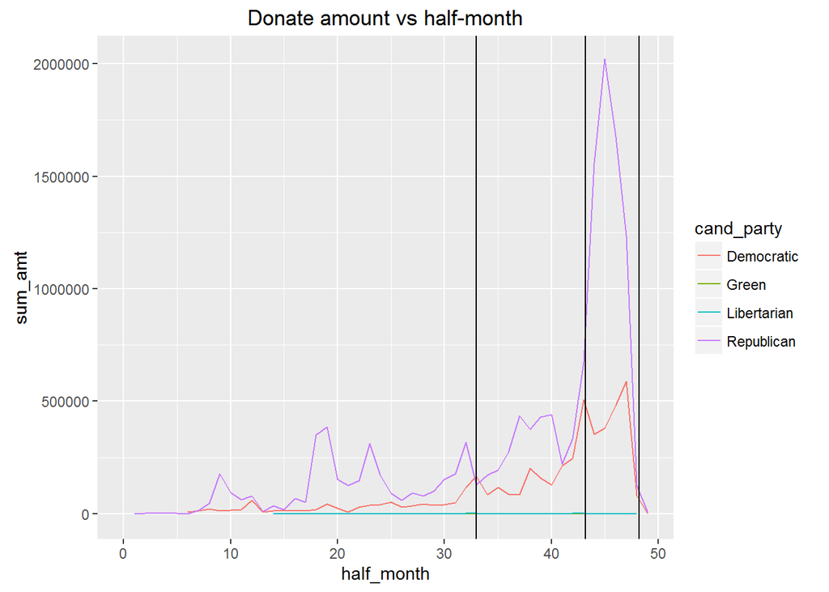

The first graph is regrading donation number and the second one is regarding donation amount. To make plot smoothier, in the second graph, I set the X-aixs as half_month(two weeks) and aggregate the amount of donation within the 2 weeks as y-axis.

From the first graph, we get to know that with the time being approaching to the ballot day, donation number increased sharply and party supporters became more active. In the second graph, the first vertical solid line from the left side represents the day when Romney became the only one competitve candidate inside Republican, and the second vertical line represents the day when Romney was formally nominated by Republican, and the third line represents the elective day. As we can see, Republican had greater advantages on donation amount over Democratic at almost every time period. Republican candidates had more stable donation resource.

Next I would like to learn the time when richer persons donated money. I only consider those who donated 500 or more dollars.

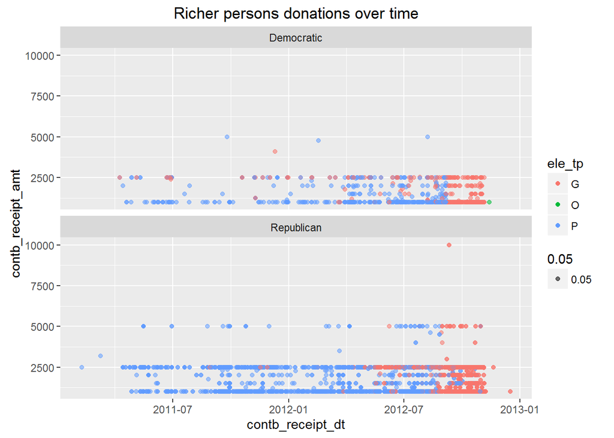

As we learned from the graph, richer persons tend to come forward later. A lot of 5000 dollars donation to Republican candidate appeared and 2500 dollars point became denser after July 2012.

In the following part, even though I will be analyzing data grouped by party, I will pay more attention to features of donators. Where did supportes of each party live in? What were their occupation?

## Donation and donators

I would like to see the regional distribution of Republican and Democratic supporters by looking into the donators number and amount of donation in major cities here in TN. I define major cities by extracting a city list of 30 cities with greatest number of donators.

```
## Source: local data frame [30 x 3]
##
##     contbr_city     n   sum_amt
##          (fctr) (int)     (dbl)
## 1     NASHVILLE 14078 3750490.3
## 2       MEMPHIS  8446 2227087.9
## 3     KNOXVILLE  8350 2256218.9
## 4     BRENTWOOD  3210 1023548.9
## 5      FRANKLIN  3066  845679.9
## 6   CHATTANOOGA  3059  735912.1
## 7    GERMANTOWN  2109  587136.7
## 8  MURFREESBORO  1781  257411.4
## 9     OAK RIDGE  1250  174416.3
## 10      CORDOVA  1228  175750.6
## ..          ...   ...       ...
```

```
##         contbr_city Democratic Republican
## 12          ANTIOCH        550        104
## 26         BARTLETT        316        263
## 53        BRENTWOOD       1579       1631
## 57          BRISTOL        163        260
## 87      CHATTANOOGA       1884       1170
## 95      CLARKSVILLE        649        461
## 97        CLEVELAND        313        387
## 103    COLLIERVILLE        492        694
## 108      COOKEVILLE        401        277
## 110         CORDOVA        805        417
## 122      CROSSVILLE        361        430
## 177        FRANKLIN       1582       1483
## 181        GALLATIN        241        326
## 185      GERMANTOWN        898       1209
```

[output cut: 16 more lines]

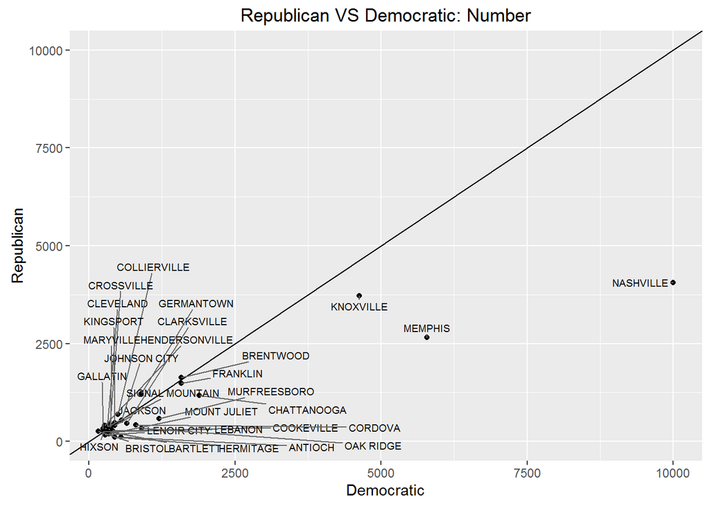

```
##         contbr_city Democratic Republican
## 12          ANTIOCH   27236.01    9427.07
## 26         BARTLETT   23828.00   51759.12
## 53        BRENTWOOD  225773.90  797775.05
## 57          BRISTOL   12100.75  109686.02
## 87      CHATTANOOGA  210805.64  524156.42
## 95      CLARKSVILLE   48088.97  121810.25
## 97        CLEVELAND   18818.64  177284.14
## 103    COLLIERVILLE   53007.05  235671.16
## 108      COOKEVILLE   28240.00   97245.66
## 110         CORDOVA   57276.60  118076.01
## 122      CROSSVILLE   25994.75   89671.65
## 177        FRANKLIN  146019.09  699410.78
## 181        GALLATIN   25114.80  122194.15
## 185      GERMANTOWN  103682.75  482953.92
```

[output cut: 16 more lines]

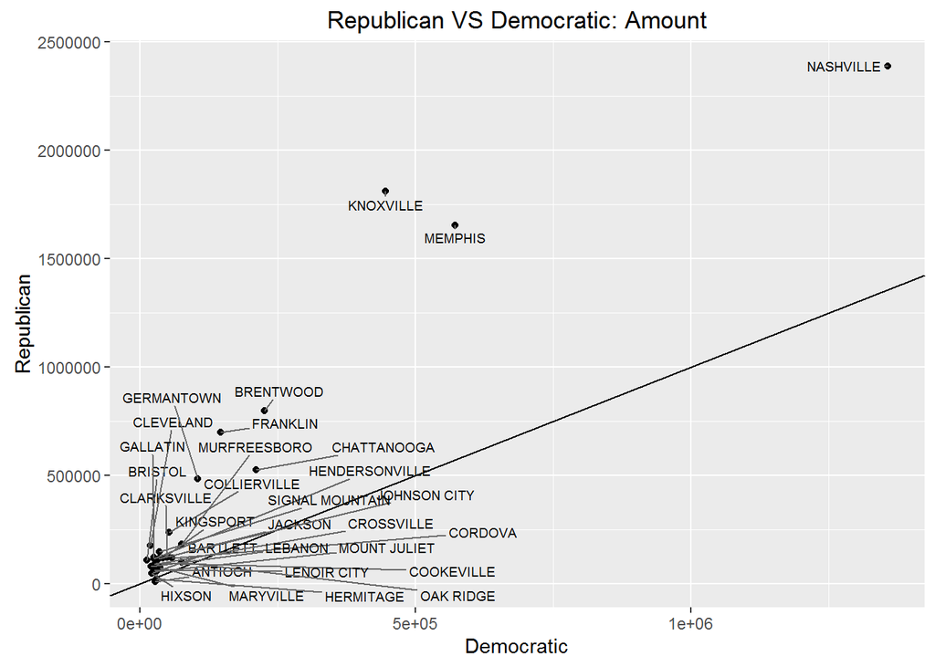

The solid lines on each graph are places on which Republican equals to Democratic. From the 2 graphs above, I get that even though Republican won Democratic in all most all major cities based on amount of donation, Democratic won in most major cities based on number of donators, especially in big cities, like Nashville , Memphis, where number of Democratic supporters are more than two times than that of Republican supporters.

The following graph will show the top 20 donation number distribution by zip code.

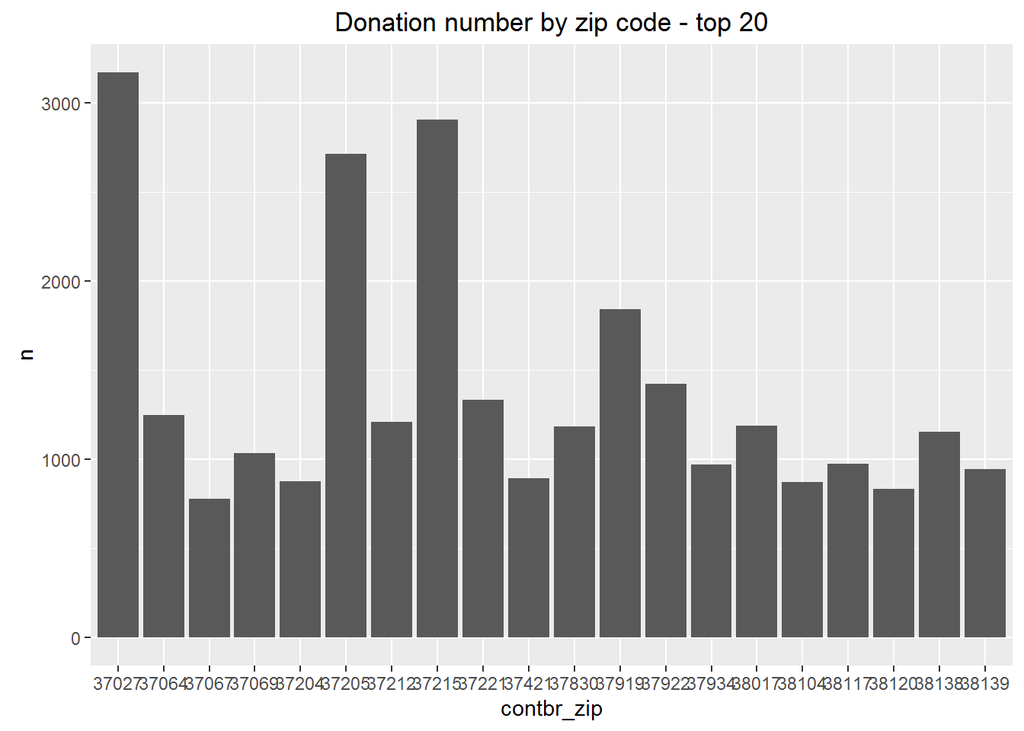

Then I want to learn more about big donators. Where did big donators live in?

```
## Source: local data frame [10 x 3]
##
##         contbr_city     n sum_amt
##              (fctr) (int)   (dbl)
## 1         NASHVILLE  1330 2489248
## 2         KNOXVILLE   945 1462549
## 3           MEMPHIS   848 1519373
## 4         BRENTWOOD   383  655357
## 5          FRANKLIN   311  587540
## 6       CHATTANOOGA   265  461883
## 7        GERMANTOWN   221  384685
## 8  LOOKOUT MOUNTAIN    83  162361
## 9      COLLIERVILLE    80  142769
## 10  SIGNAL MOUNTAIN    75  106367
```

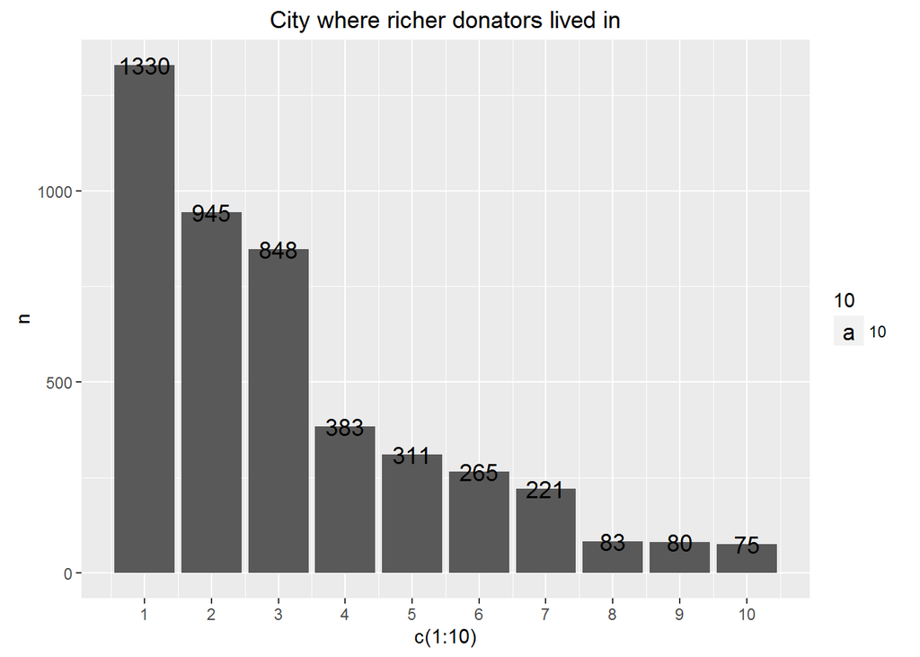

We can see that Nashville, Knoxville and Memphis have the largest number of richer donators. However, it does not make sense as total number of donators was not considered. Thus I want to show the ratio of richer donators and pick up 10 cities with highest richer donators rate. In order to make it statistically useful, I only take cities with at least 500 donators into consideration.

```
## Source: local data frame [10 x 4]
##
##        contbr_city     n sum_rich  rich_rate
##             (fctr) (int)    (int)      (dbl)
## 1        BRENTWOOD  3210      383 0.11931464
## 2        KNOXVILLE  8350      945 0.11317365
## 3  SIGNAL MOUNTAIN   698       75 0.10744986
## 4       GERMANTOWN  2109      221 0.10478900
## 5         FRANKLIN  3066      311 0.10143509
## 6          MEMPHIS  8446      848 0.10040256
## 7        CLEVELAND   700       70 0.10000000
## 8         GALLATIN   567       55 0.09700176
## 9        NASHVILLE 14078     1330 0.09447365
## 10     CHATTANOOGA  3059      265 0.08662962
```

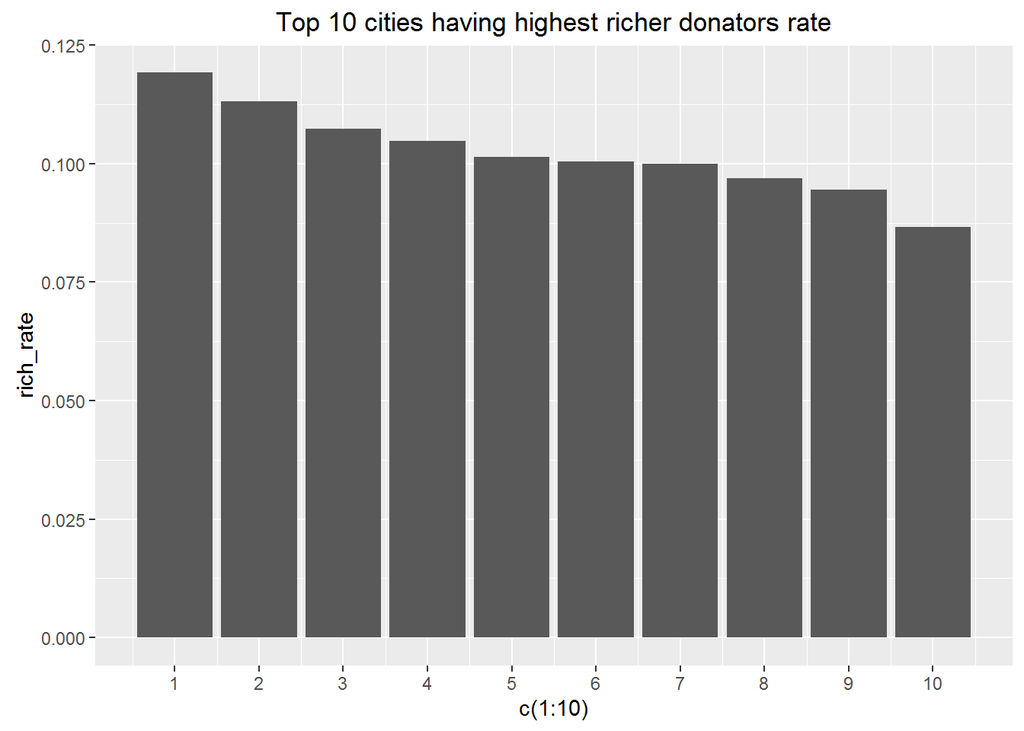

The result is not surprising. Brentwood and Knoxville are rich districts. On the contrary, though Nashville and Memphis have a great number of richer donators, the non-rich should be even more.

I am also interested in differences among retired, employed and unemployed donators. What were the amount distribution for the three groups? Which party do they each support more?

Count the number of each group.

```
##
##   employed    retired unemployed
##      57639      19210        450
```

Summary of retiree donation

```
##    Min. 1st Qu.  Median    Mean 3rd Qu.    Max.
## -2500.0    25.0    56.0   177.6   125.0  5000.0
```

Summary of employed people donation

```
##    Min. 1st Qu.  Median    Mean 3rd Qu.    Max.    NA's
## -5000.0    25.0    56.0   228.1   200.0 10000.0       7
```

Summary of unemployed people donation

```
##    Min. 1st Qu.  Median    Mean 3rd Qu.    Max.
##     3.0    19.0    35.0   109.2    60.0  2500.0
```

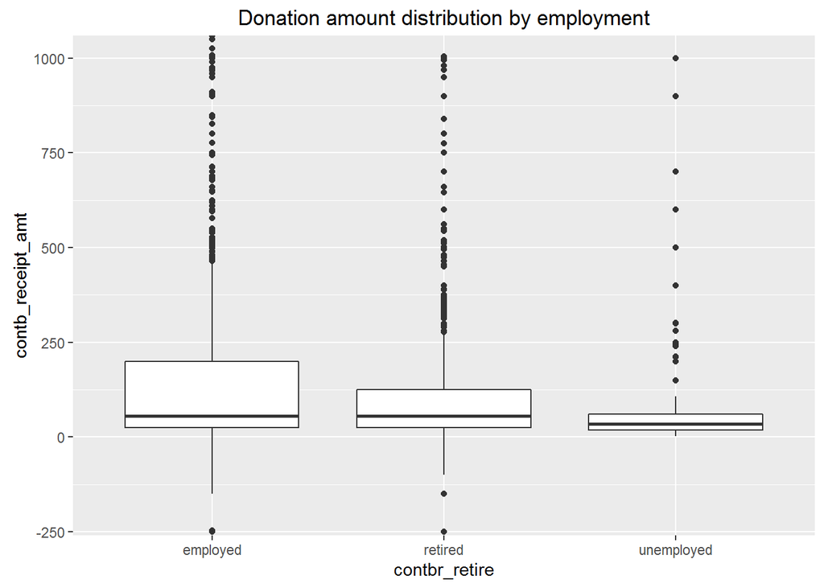

See from the graph that employed groups have the largest portion of higher donators, and then followed by retirees, and then unemployed. Next I am gonna display their part affiliations.

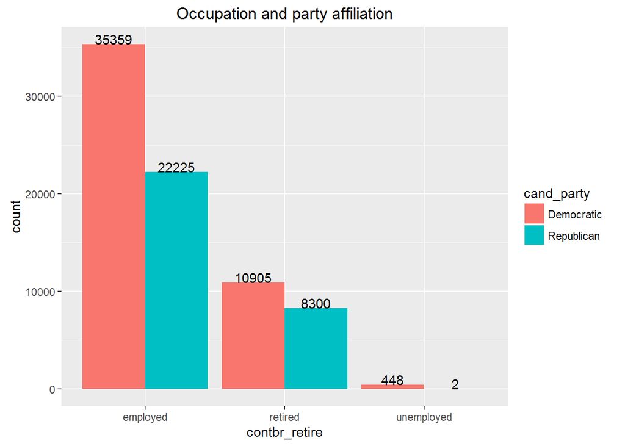

This result shows that compared to retirees, employed donators support Democratic more. All unemployed donators except two support Democratic.

I wish to learn about political affiliation by their occupations. I tabled the data by occupation and read through top 100 with the greatest count number.It is impossible to group them one by one so I choose 5 easily recognizable occupations, physician, homemaker, attorney, teacher and student, where attorney includes attorney and lawyer labeled, and teacher includes professor, teacher as well as college professor. Table the 5 occupations.

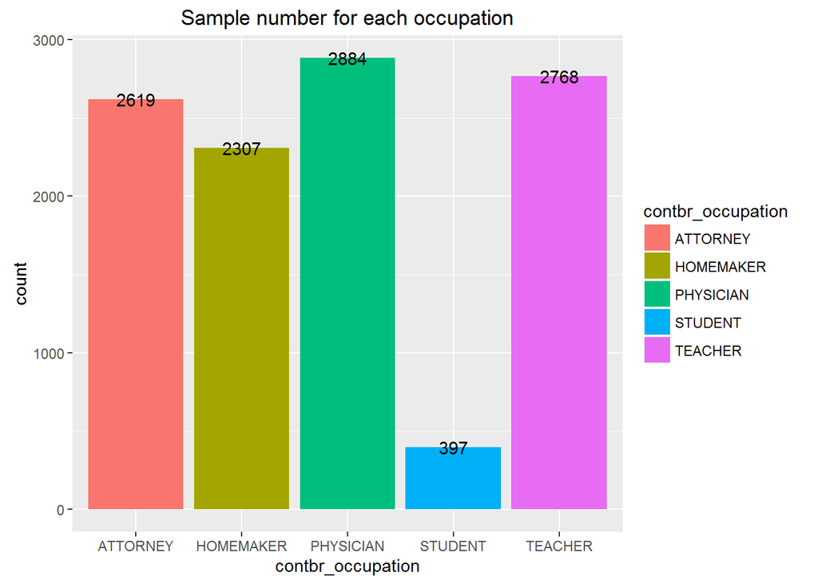

Then I am gonna see their donation amount distribution. summary of attorney donation distribution.

```
##    Min. 1st Qu.  Median    Mean 3rd Qu.    Max.
## -2500.0    50.0   100.0   325.7   250.0  2500.0
```

summary of homemaker donation distribution.

```
##    Min. 1st Qu.  Median    Mean 3rd Qu.    Max.
## -2500.0    35.0   100.0   444.0   280.5  5000.0
```

summary of physician donation distribution.

```
##    Min. 1st Qu.  Median    Mean 3rd Qu.    Max.
## -2500.0    50.0   100.0   317.9   250.0  4000.0
```

summary of student donation distribution.

```
##    Min. 1st Qu.  Median    Mean 3rd Qu.    Max.
##     2.0    10.0    25.0   134.6   100.0  2500.0
```

summary of teacher donation distribution.

```
##    Min. 1st Qu.  Median    Mean 3rd Qu.    Max.
## -2500.0    20.0    50.0   103.8   100.0  5000.0
```

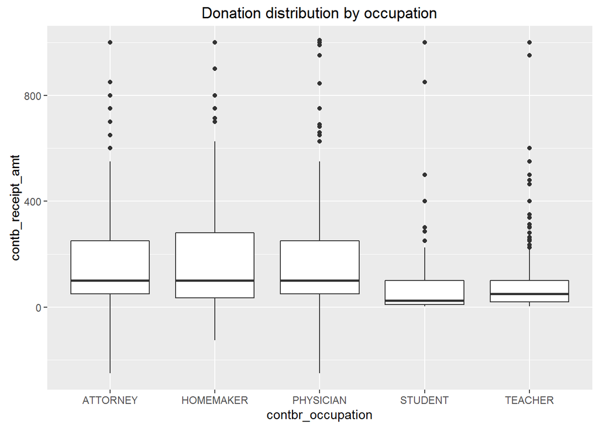

Student and teacher’s median values are relatively less than other three occupations.Homemakers are more generous. Then show their political affiliation.

```
## Source: local data frame [12 x 4]
## Groups: contbr_occupation [?]
##
##    contbr_occupation  cand_party     n   sum_amt
##               (fctr)      (fctr) (int)     (dbl)
## 1           ATTORNEY  Democratic  1804 401104.54
## 2           ATTORNEY  Republican   815 451952.57
## 3          HOMEMAKER  Democratic   985 162548.70
## 4          HOMEMAKER  Republican  1322 861800.70
## 5          PHYSICIAN  Democratic  1310 231659.67
## 6          PHYSICIAN Libertarian     2    500.00
## 7          PHYSICIAN  Republican  1572 684721.37
## 8            STUDENT  Democratic   248  16290.25
## 9            STUDENT  Republican   149  37161.60
## 10           TEACHER  Democratic  2519 221255.53
## 11           TEACHER       Green     3    750.00
## 12           TEACHER  Republican   246  65320.64
```

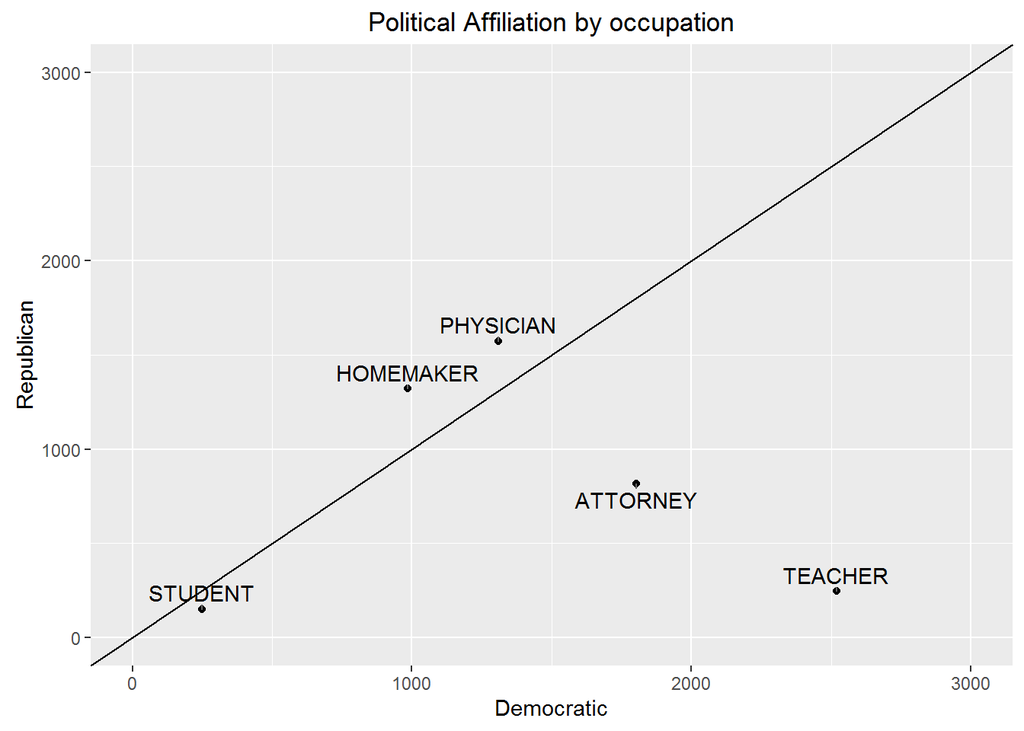

Attorneys and teachers are extrmemly apt to Democratic. Homemakers and physicians support Republican more. Students’ political affiliation stands next to neutral.

# Final plots and summary

Finally, by exploring the data, I tried to answer the question: Which kind of persons support Democratic or Republican? I tried to describe these two groups of people using data and graphs.

The first plot is the one reflecting average donation amount per person for each candidate. The reason why I drew this picture is because in the previous analysis, I found that the amount of donation Republican received was much higher than Democratic, but the number of donators for Democratic was higher than Democratic and I was curious abount how much gap they have on average donation amount per donator.

## Plot one

[figure not shown]

Knowing that the poorer were supporting Democratic, I would like to know about the regional distribution of donators. So I drew the following graph.

## Plot two

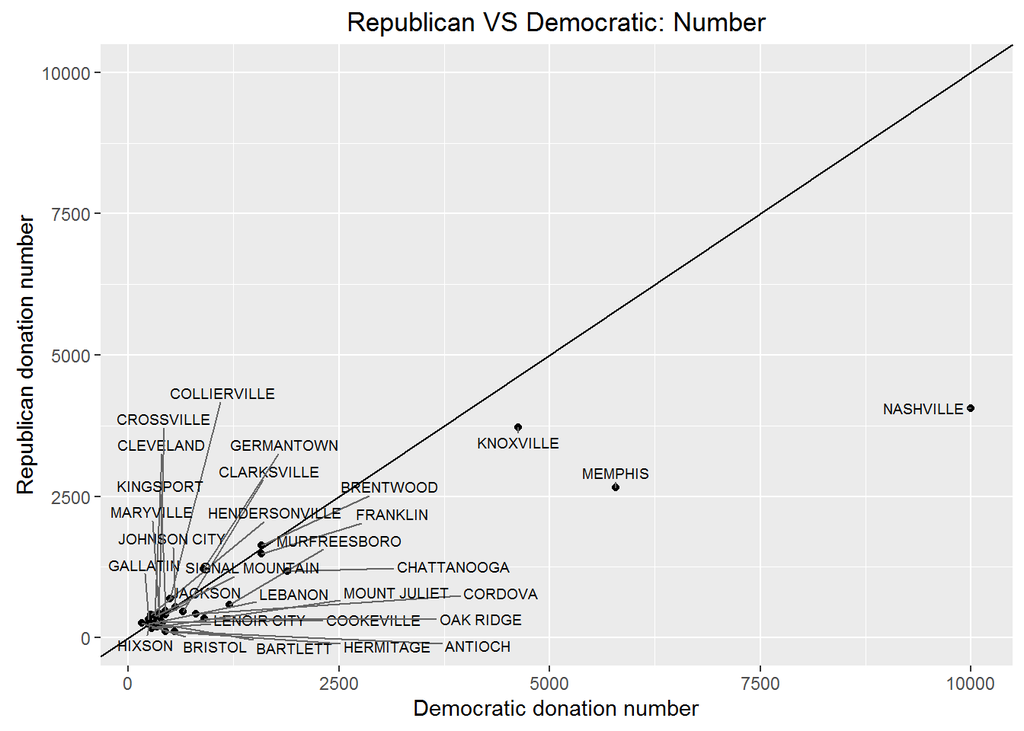

And next I moved to the time distribution of donations for each party.

## Plot three

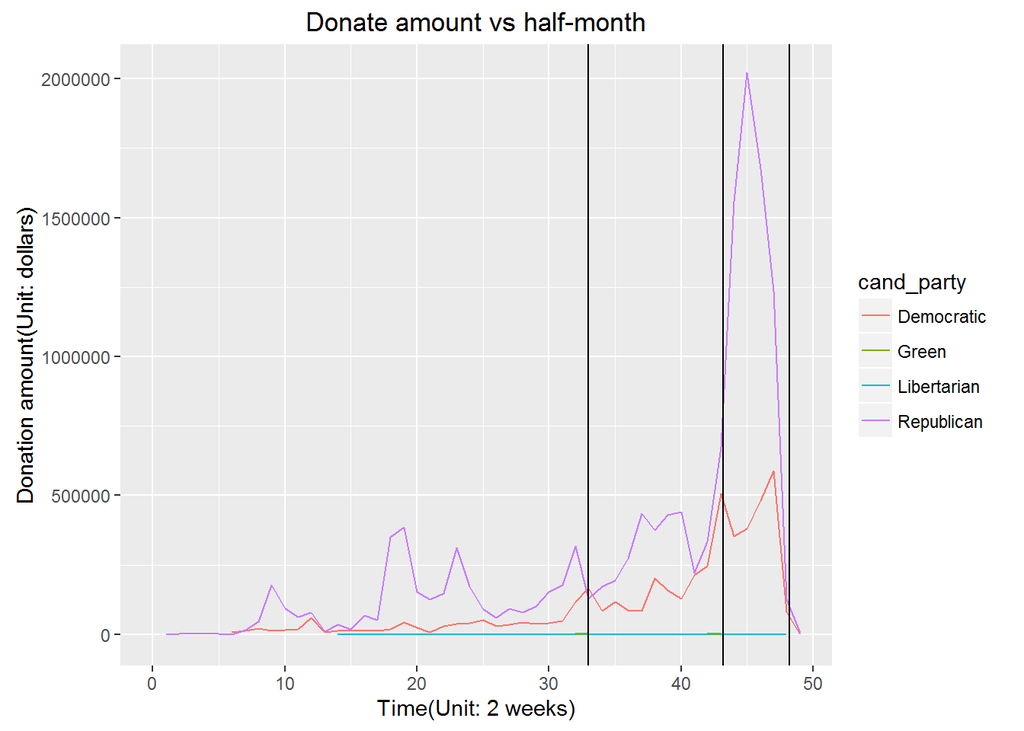

So the answer for the previous question is that people of middle and upper middle class tended to support Republican while lower middle and ever poorer electorate tended to support Democratic in state of Tenneessee. People living in big cities tended to donate to Democratic. However, Republican candidates were able to gain more funds from richer persons over time.

# Reflection

I found so many funny things by exploring the dataset and I think they are meaningful. The process was not too tricky because variables contained are less. The three packages, ggplot2, reshape2 and dplyr were helpful. I am able to handle problems with the help of them. However, I think some more tricky questions can be added into the analysis to further improve and complete the project.

- Try analysing the more relationship between donators occupation and their political affiliate. It requires us to group their occupation precisely.
- Compare Romney and other Republican candidates.
- Try exploring relationship between gender and donation amount per person, gender and political affiliate. However, the current dataset lack relevant information. We can group them by mapping their names to gender, which would be supposed to cause biasness.

I need to practice R often and learn more about R command later but thanks for the experience.